# Math Journal

D. Zack Garza

University of Georgia  
dzackgarza@gmail.com

Last updated: 2021-07-03

# 1 Fargues-Fontaine Stuff

Useful references:

- [Some intro/motivations](https://www.mathi.uni-heidelberg.de/fg-sga/docs/Programm_la-courbe.pdf)
  - Also has a good outline for seminar later?
- https://www.math.ias.edu/~lurie/205notes/Lecture1-Overview.pdf
- https://www.math.ias.edu/~lurie/205notes/Lecture6-Curve.pdf
- [Morrow’s article](http://www.bourbaki.ens.fr/TEXTES/Exp1150-Morrow.pdf)
- https://www.math.uni-bonn.de/people/ja/thecurve/vorlesung_the_curve.pdf
- http://www.math.columbia.edu/~phlee/SeminarNotes/FarguesFontaine.pdf

## 1.1 Motivation / Summary

Some notes on the Fargues-Fontaine curve ${X_\mathrm{FF}}$, the fundamental curve of $p{\hbox{-}}$adic Hodge theory.

What’s the point? There’s supposed to be a “curve” ${X_\mathrm{FF}}$ over ${ {\mathbb{Q}}_p }$ where local Langlands for ${ {\mathbb{Q}}_p }$ should be encoded as geometric Langlands on ${X_\mathrm{FF}}$, which glues together important period rings from $p{\hbox{-}}$adic Hodge theory. Stems from conjectures of Grothendieck wanting to related de Rham cohomology to étale cohomology, and a similar theorem proved by Faltings in the 80s. Hot topic right now because of a conjecture related to local Langlands: supposed to give a way to go from the Galois side to the automorphic side. Important object: $\mathop{\mathrm{Bun}}_G$, the moduli stack of $G{\hbox{-}}$bundles for $G$ a reductive algebraic group over a local field over a family of ${X_\mathrm{FF}}$ curves.

A useful overall analogy: it’s like the Riemann sphere ${\mathbb{CP}}^1 \mathrel{\vcenter{:}}={\mathbb{P}}^1({\mathbb{C}})$, and in fact the adic version is a $p{\hbox{-}}$adic Riemann surface. The full ring of meromorphic functions on ${\mathbb{P}}^1({\mathbb{C}})$ is ${\mathbb{C}}\qty{z}$, but ${\mathbb{C}}[z]$ captures most of the data away from $\infty$. ${\mathbb{C}}[z]$ as a ${\mathbb{C}}{\hbox{-}}$algebra consists of regular (polynomial) functions on ${\mathbb{P}}^1({\mathbb{C}})$ with a pole at $\infty$ of order equal to the degree of the polynomial. View the ${\mathbb{Z}}{\hbox{-}}$algebra ${\mathbb{Z}}$ as the regular functions on $P$ the set of primes (finite places), with a point at $\infty$ (infinite place) given by the usual valuation ${\left\lvert {{-}} \right\rvert}$. Make this more algebro-geometric by replacing ${\mathbb{Z}}$ with either ${ {\mathbb{Z}}_p }$ or ${ {\mathbb{Q}}_p }$ (so $p{\hbox{-}}$adic things) and looking at ${ {\mathbb{Q}}_p }{\hbox{-}}$algebras $B$ as replacements for regular functions. ${X_\mathrm{FF}}$ is also supposed to “geometrize” period rings from $p{\hbox{-}}$adic Hodge theory. One can also geometrize class field theory somehow, and realize $\operatorname{Gal}(\mkern 1.5mu\overline{\mkern-1.5mu{\mathbb{Q}}\mkern-1.5mu}\mkern 1.5mu/{\mathbb{Q}})$ as some kind of fundamental group.

${X_\mathrm{FF}}$ is also roughly a moduli of “untilts,” which allow passing between ${\mathbb{F}}_p$ and ${ {\mathbb{Q}}_p }$. A major goal is to go from characteristic zero to characteristic $p$ (relatively easy) and then to go back to characteristic zero (relatively hard). The curve is useful because many linear algebraic objects of $p{\hbox{-}}$adic theory can be translated into vector bundles over ${X_\mathrm{FF}}$, and there is “Grothendieck splitting” type of theorem for those.

*Todos*: motivate

- Perfectoid spaces
- Tilts/untilts
- Galois representations (might have notes elsewhere..?)
- Langlands, period!
- Absolute Galois groups, particularly $G({ \mkern 1.5mu\overline{\mkern-1.5mu \mathbb{Q} \mkern-1.5mu}\mkern 1.5mu }/{\mathbb{Q}})$ (see notes elsewhere)
- Relations to homotopy theory: an isomorphism of Lubin-Tate, and the Drinfeld tower?

### 1.1.1 Definitions

- *Curve*: over $k= { \mkern 1.5mu\overline{\mkern-1.5muk\mkern-1.5mu}\mkern 1.5mu }$, an integral separated scheme of finite type over $k$ of dimension 1.
- *Finite type*: on affines, when $\operatorname{Spec}A\to \operatorname{Spec}B$ induces $B\to A$ making $A \in \mathsf{B}{\hbox{-}}\mathsf{Mod}$ finitely generated.
- *Algebraic curve*: $X$ of pure Krull dimension 1, or equivalently $X$ has an affine open cover $\left\{{\operatorname{Spec}R_i}\right\}_{i\in I} \rightrightarrows X$ where each $\operatorname{Spec}R_i$ is Krull dimension 1.
  - For (irreducible) varieties over $k= { \mkern 1.5mu\overline{\mkern-1.5muk\mkern-1.5mu}\mkern 1.5mu }$, just an algebraic variety of dimension 1.
- *Complete curve*: for algebraic varieties $X$, universally closed: the projections $X\times({-})\to({-})$ are closed maps when evaluated on any variety.

### 1.1.2 Main Results

- Why care about tilts/untilts: for $k$ a field and $X\mathrel{\vcenter{:}}=\operatorname{Spec}{\mathbb{Q}}$ as a scheme, characteristic zero tilts of $k$ are a good replacement for $X(k)$ which makes $X\times X$ nontrivial.
- Main theorem: if $k = { \mkern 1.5mu\overline{\mkern-1.5muk\mkern-1.5mu}\mkern 1.5mu }$ is a completely valued characteristic $p$ field, then there exists a Dedekind scheme $X \to \operatorname{Spec}{ {\mathbb{Q}}_p }$ whose closed points $x$ correspond to (isomorphism classes) of characteristic 0 untilts of $k$, modulo the action of the Frobenius $\varphi(x) = x^p$.
  - So moduli of untilts of a perfectoid field, behaves like open disc in ${\mathbb{C}}$. The unique characteristic $p$ untilt is like $z=0 \in {\mathbb{C}}$.
- Why the FF “curve” isn’t a curve: it’s a scheme over ${ {\mathbb{Q}}_p }$, but not finite-type: specifically, the structure morphism $X\to \operatorname{Spec}{ {\mathbb{Q}}_p }$ is not finite type.
  - Why not finite type? Since if $x\in X$ is a closed point then the residue field $\kappa(x) / { {\mathbb{Q}}_p }$ is not a finite extension.
  - Incidentally, $\kappa(x)$ is exactly the untilt of $k$ corresponding to $x$.
- Nice properties of ${X_\mathrm{FF}}$ coinciding with curves:
  - $\sum \deg_f(x) = 0$ for every rational function $f$ on ${X_\mathrm{FF}}$, similar to being projective/complete as a scheme/variety.
    - Note: very similar to a theorem from complex analysis: sum of orders of poles and zeros equals zero for a meromorphic function on ${\mathbb{P}}^1({\mathbb{C}})$.
  - Line bundles are classified by degree
  - $H^1(C, {\mathcal{O}}_C) = 0$, similar to having genus $g=0$.
    - Usually it’s like $2g = \operatorname{rank}H^1$
  - The structure morphism $X\to \operatorname{Spec}{ {\mathbb{Q}}_p }$ has simply connected fibers
- Useful heuristics:

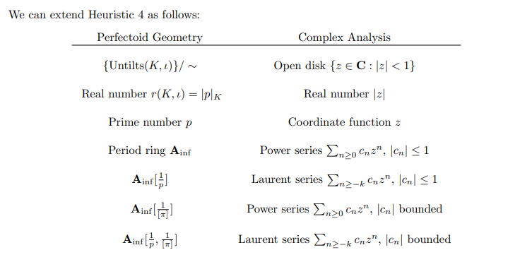

## 1.2 Constructing the curve

Notation:

- $B_{\varepsilon}\mathrel{\vcenter{:}}= B^{\varphi = 1}_{\mathrm{crys}}$
- ${\mathbb{A}}_\inf(K) \mathrel{\vcenter{:}}= W(K^ { \flat } )$, i.e. just Witt vectors of the tilt.
  - Supposed to interpolate between the $\char 0$ geometry of $K$ and $\char p$ geometry of $K^ { \flat }$.
  - Importantly, even if $K$ doesn’t have Frobenius, $K^ { \flat }$ does! This will yield an action of Frobenius on cohomology – this is probably used to set up trace formulas.

### 1.2.1 Method 1: Schematically, Proj Construction

- Punchline: ${X_\mathrm{FF}}= \mathop{\mathrm{Proj}}\qty{\bigoplus_{n\geq 0} B^{\varphi = p^n}}$ as a scheme.
- $B^{\varphi = p^n}$ are the elements in $B$ where $\varphi(x) = p^n x$ where $\varphi$ is the Frobenius.
- $B \mathrel{\vcenter{:}}=\mathop{\mathrm{colim}}\nolimits_{I\subseteq [0, 1] \subset {\mathbb{R}}} B_{I}$ is a $p{\hbox{-}}$adic Frechet space
  - Supposed to look like holomorphic functions of $p$.
- For $I\mathrel{\vcenter{:}}=[a, b]$, $B_{[a, b]}$ is the completion of $W({\mathcal{O}}_C^ { \flat } ) { \left[ {{1\over p}, {1\over {\left\lvert {\pi } \right\rvert}}} \right] }$ with respect to Gauss norms, where $W$ denotes the Witt vectors, and we’ve localized at $p$ and $\pi$ a pseudo-uniformizer.
- Other notation used:
- Alternatively using the Riemann sphere analogy: ${\mathbb{P}}^1({\mathbb{C}})$ can be recovered as a proj. Write ${\operatorname{Fil}}_k {\mathbb{C}}[z] \mathrel{\vcenter{:}}=\left\{{f\in {\mathbb{C}}[z] {~\mathrel{\Big|}~}\deg f \leq k}\right\}$ to be the $k$th filtered piece using a filtration by degree.
- The claim is that ${\mathbb{P}}_1({\mathbb{C}}) \cong \mathop{\mathrm{Proj}}\qty{\bigoplus_{k\geq 0} {\operatorname{Fil}}_k {\mathbb{C}}[z]}$.
  - Somehow this uses that ${\mathbb{C}}[z_0, z_1] \xrightarrow{\sim} \bigoplus_{k\geq 0} {\operatorname{Fil}}_k {\mathbb{C}}[z]$, no clue..
- By analogy, maybe ${X_\mathrm{FF}}= \mathop{\mathrm{Proj}}\qty{ \bigoplus_{k\geq 0} {\operatorname{Fil}}_k B_{\varepsilon}}$ where ${\operatorname{Fil}}_k B_{\varepsilon}\mathrel{\vcenter{:}}=\left\{{b\in B_{\varepsilon}{~\mathrel{\Big|}~}v(b) \geq k}\right\}$, where we take a valuation $v$ coming from $B_\mathrm{dR}$.
- There is a subalgebra $B_{\mathrm{crys}}^+ \subseteq B_{\mathrm{crys}}$ where $B_{\mathrm{crys}}^+{ \left[ { \scriptstyle \frac{1}{t} } \right] } \cong B_{{\mathrm{crys}}}$ for some $t$, plus some other properties.
- Can then obtain
  $$\begin{align*}
  {X_\mathrm{FF}}= \mathop{\mathrm{Proj}}\qty{\bigoplus _{k\geq 0} \qty{B_{\mathrm{crys}}^+}^{\varphi = p^k}}
  .\end{align*}$$

#### 1.2.1.1 Informal Description

Glue together *period rings*: an affine scheme to a formal disk along a formal punctured disc, so like
$$\begin{align*}
{X_\mathrm{FF}}= \operatorname{Spec}B_{{\mathrm{crys}}}^{\varphi = 1} { \displaystyle\coprod_{\operatorname{Spec}B_{\mathrm{dR}}} } \operatorname{Spec}B_{\mathrm{dR}}^+
.\end{align*}$$

- $\operatorname{Spec}B_{{\mathrm{crys}}}^{\varphi = 1}$ is an affine scheme.
- $\operatorname{Spec}B_{\mathrm{dR}^+}$ is a formal disk.
- $\operatorname{Spec}B_{\mathrm{dR}}$ is a formal punctured disk.
- $B_\mathrm{dR}$ is a *period ring*, cooked up to relate $H^*_\mathrm{dR}(Y)$ to $H^*_{\text{ét}}(Y_{\mkern 1.5mu\overline{\mkern-1.5muK\mkern-1.5mu}\mkern 1.5mu}; { {\mathbb{Q}}_p })$ when $Y$ is the generic fiber of a scheme over $W(k)$ and $Y_{\mkern 1.5mu\overline{\mkern-1.5muK\mkern-1.5mu}\mkern 1.5mu} \mathrel{\vcenter{:}}= Y \underset{\scriptscriptstyle {\operatorname{Spec}K} }{\times} \operatorname{Spec}\mkern 1.5mu\overline{\mkern-1.5muK\mkern-1.5mu}\mkern 1.5mu$ (see *Crystalline comparison conjecture*).
  - $B_{\mathrm{dR}}$ is a complete DVR, a field, and a (very large) ${ {\mathbb{Q}}_p }{\hbox{-}}$algebra with residue characteristic zero, and $B_{{\mathrm{crys}}} \leq B_{\mathrm{dR}}$ is a subring.
- $B_\mathrm{dR}^+$ is its valuation ring (or place), i.e. a subring such that for every element $x$ of $\operatorname{ff}(B_{\mathrm{dR}})$, either $x \in B_{\mathrm{dR}}^+$ or $x^{-1}\in B_{\mathrm{dR}}^+$.
  - This is supposed to be like a ring of integers ${\mathcal{O}}_K$ for a number field $K$. It is non-canonically isomorphic to the $p{\hbox{-}}$adic Laurent field ${\mathbb{C}}_p((t))$.
- So it’s like the one-point compactification of $\operatorname{Spec}$ of the period ring of $p{\hbox{-}}$adic Hodge theory.
- This is supposed to look like building the Riemann sphere ${\mathbb{P}}^1({\mathbb{C}})$ as ${\mathbb{C}}[z]$ (regular away from $\infty)$ glued to ${\mathbb{C}}\dqty{1\over z}$ (germs of meromorphic functions at $\infty$).
  - $B_{{\mathrm{crys}}}^{\varphi = 1}$ is supposed to look like ${\mathbb{C}}[z]$. Classically, ${\mathbb{C}}\qty{z}$ is the full field of meromorphic functions on ${\mathbb{CP}}^1$, and ${\mathbb{C}} { \left[ {z} \right] }$ are regular functions on ${\mathbb{CP}}^1\setminus\left\{{\infty}\right\}$.
  - And $B_\mathrm{dR}$ is like ${\mathbb{C}}\dqty{1\over z}$, germs of meromorphic functions at infinity.
  - Taking ${\mathbb{CP}}^1$ and puncturing at a point yields a disc, so ${\mathbb{CP}}^1\setminus\left\{{\infty}\right\}, {\mathbb{CP}}^1\setminus\left\{{0}\right\}$ are discs. Their overlap is ${\mathbb{CP}}^1\setminus\left\{{\infty, 0}\right\} \cong {\mathbb{D}}\setminus\left\{{0}\right\}$, a disc punctured at $z=0$.

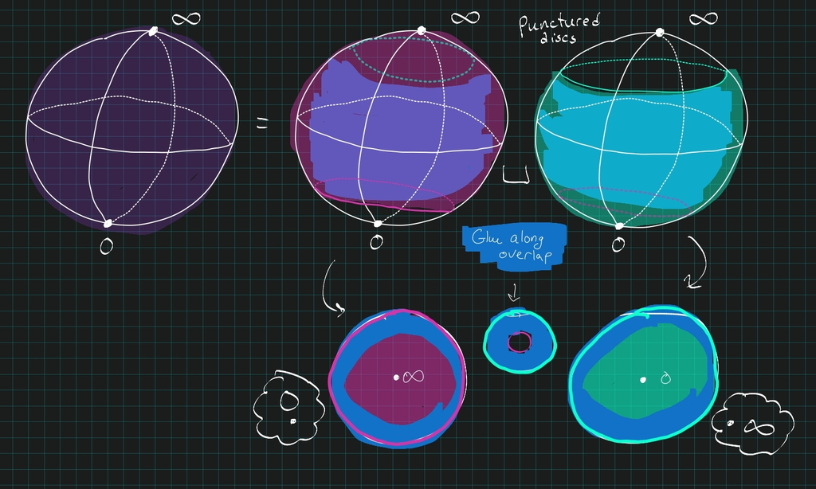

## 1.3 Other Random Notes

- Much like ${\mathbb{P}}^1({\mathbb{C}})$, we have a Grothendieck splitting principle: every vector bundle ${\mathcal{E}}\to {X_\mathrm{FF}}$ splits uniquely as ${\mathcal{E}}\cong \bigoplus_{k=1}^m {\mathcal{O}}_{{X_\mathrm{FF}}}(\lambda _k)$ where $\lambda_k \in {\mathbb{Q}}$ are weakly decreasing and ${\mathcal{O}}_{{X_\mathrm{FF}}}(\lambda)$ is a (somewhat complicated) rational twist.
  - Proof uses $p{\hbox{-}}$divisible groups, can be used to answer questions in $p{\hbox{-}}$adic Hodge theory (e.g. about Galois representations).
- Needs Scholze’s theory of diamonds: Weil’s proof of RH for curves uses the surface $X\underset{\scriptscriptstyle {{\mathbb{F}}_q} }{\times} X$ for $X$ a curve (this surface is also used in shtuka theory in geometric Langlands), need a similar object in arithmetic geometry that should morally look like ${\mathbb{Z}}\otimes_{{\mathbb{F}}_1} {\mathbb{Z}}$.
- $H^1({X_\mathrm{FF}}; {\mathcal{O}}_{{X_\mathrm{FF}}}) = { {\mathbb{Q}}_p }$, which can apparently be computed using Čech cohomology and the fundamental exact sequence:
  $$\begin{align*}
  0 \longrightarrow \mathbb{Q}_{p} \longrightarrow B_{e} \longrightarrow B_{\mathrm{dR}} / B_{\mathrm{dR}}^{+} \longrightarrow 0
  .\end{align*}$$

# 2 Bibliography